# Unit 4: General Factorial Design

## 2.1 Fit Additive Models without Interaction Term

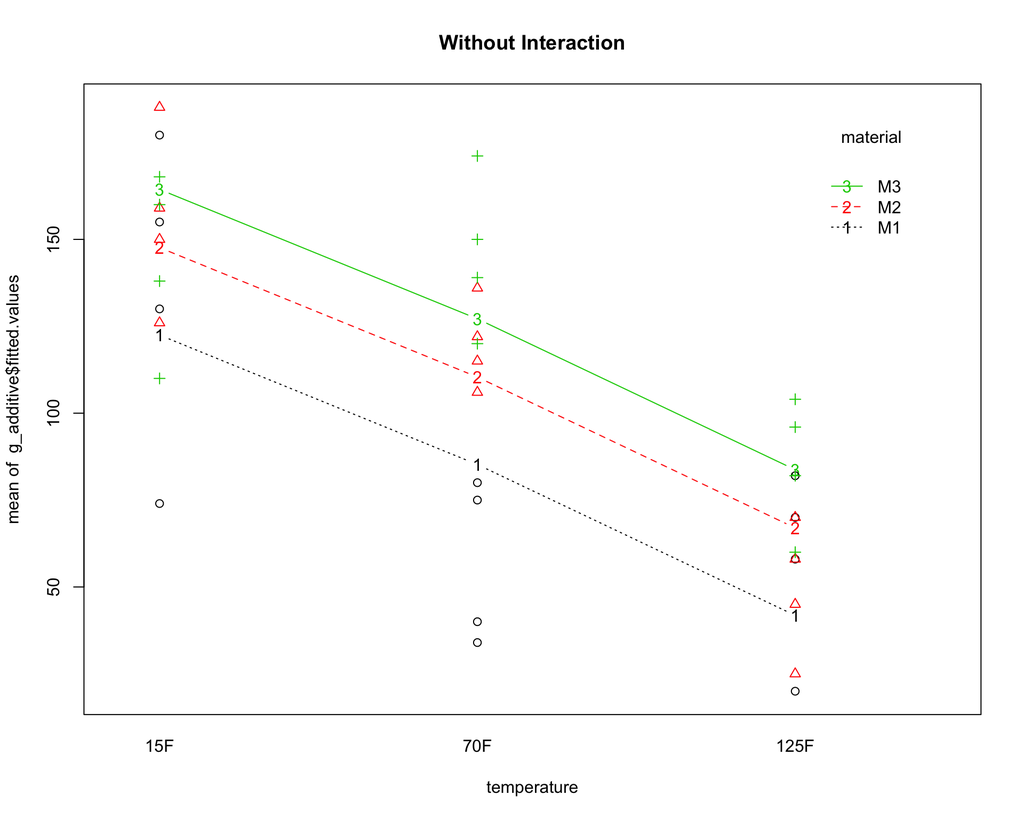

```r
# fit the model without interaction (wrong analysis)
g_additive <- lm(response ~ material+temperature, battery)
interaction.plot(temperature,material,  g_additive$fitted.values, col = 1:3,
                 ylim = range (response), main = "Without Interaction", type = "b")
points (temperature, response,  col = material,   pch = as.numeric(material))
```

## 2.2 Fit Interaction Models using “Effect Parametrization”

In this parametrization, the coefficients for "material1, material2, temperature1, temperature2 are main effects (ie, $\tau_i,\beta_j$) in the textbook, and the interaction coefficients are $(\tau\beta)_{ij}$ in the textbook.

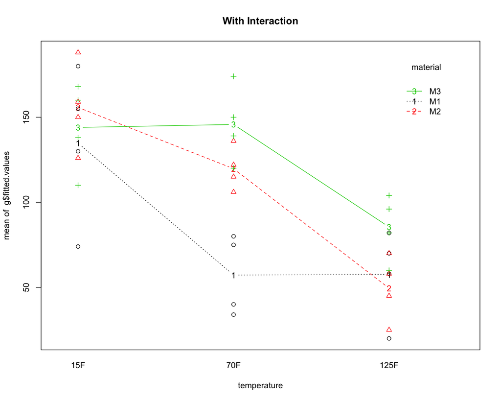

```r
g <- lm(response ~ material*temperature, battery,
        contrasts = list(material = contr.sum, temperature=contr.sum))
interaction.plot(temperature,material,  g$fitted.values, col = 1:3,
                 ylim = range (response),main = "With Interaction",
                 type = "b")
points (temperature, response, col = material, pch = as.numeric(material))
```

```r
# look at coefficients
summary(g)
```

```
##
## Call:
## lm(formula = response ~ material * temperature, data = battery,
##     contrasts = list(material = contr.sum, temperature = contr.sum))
##
## Residuals:
##     Min      1Q  Median      3Q     Max
## -60.750 -14.625   1.375  17.937  45.250
##
## Coefficients:
##                        Estimate Std. Error t value Pr(>|t|)
## (Intercept)             105.528      4.331  24.367  < 2e-16 ***
## material1               -22.361      6.125  -3.651  0.00111 **
## material2                 2.806      6.125   0.458  0.65057
## temperature1             39.306      6.125   6.418  7.1e-07 ***
## temperature2              2.056      6.125   0.336  0.73975
## material1:temperature1   12.278      8.662   1.417  0.16778
## material2:temperature1    8.111      8.662   0.936  0.35735
## material1:temperature2  -27.972      8.662  -3.229  0.00325 **
## material2:temperature2    9.361      8.662   1.081  0.28936
## ---
## Signif. codes:  0 '***' 0.001 '**' 0.01 '*' 0.05 '.' 0.1 ' ' 1
##
## Residual standard error: 25.98 on 27 degrees of freedom
## Multiple R-squared:  0.7652, Adjusted R-squared:  0.6956
## F-statistic:    11 on 8 and 27 DF,  p-value: 9.426e-07
```

```r
# look at model matrix
data.frame(battery, model.matrix(g))
```

| material | temperature | response | X.Intercept. | material1 | material2 | temperature1 | temperature2 | material1.temperature1 | material2.temperature1 | material1.temperature2 | material2.temperature2 |
| --- | --- | --- | --- | --- | --- | --- | --- | --- | --- | --- | --- |
| M1 | 15F | 130 | 1 | 1 | 0 | 1 | 0 | 1 | 0 | 0 | 0 |
| M1 | 15F | 155 | 1 | 1 | 0 | 1 | 0 | 1 | 0 | 0 | 0 |
| M1 | 15F | 74 | 1 | 1 | 0 | 1 | 0 | 1 | 0 | 0 | 0 |
| M1 | 15F | 180 | 1 | 1 | 0 | 1 | 0 | 1 | 0 | 0 | 0 |
| M1 | 70F | 34 | 1 | 1 | 0 | 0 | 1 | 0 | 0 | 1 | 0 |
| M1 | 70F | 40 | 1 | 1 | 0 | 0 | 1 | 0 | 0 | 1 | 0 |
| M1 | 70F | 80 | 1 | 1 | 0 | 0 | 1 | 0 | 0 | 1 | 0 |
| M1 | 70F | 75 | 1 | 1 | 0 | 0 | 1 | 0 | 0 | 1 | 0 |
| M1 | 125F | 20 | 1 | 1 | 0 | -1 | -1 | -1 | 0 | -1 | 0 |
| M1 | 125F | 70 | 1 | 1 | 0 | -1 | -1 | -1 | 0 | -1 | 0 |
| M1 | 125F | 82 | 1 | 1 | 0 | -1 | -1 | -1 | 0 | -1 | 0 |
| M1 | 125F | 58 | 1 | 1 | 0 | -1 | -1 | -1 | 0 | -1 | 0 |
| M2 | 15F | 150 | 1 | 0 | 1 | 1 | 0 | 0 | 1 | 0 | 0 |
| M2 | 15F | 188 | 1 | 0 | 1 | 1 | 0 | 0 | 1 | 0 | 0 |
| M2 | 15F | 159 | 1 | 0 | 1 | 1 | 0 | 0 | 1 | 0 | 0 |
| M2 | 15F | 126 | 1 | 0 | 1 | 1 | 0 | 0 | 1 | 0 | 0 |
| M2 | 70F | 136 | 1 | 0 | 1 | 0 | 1 | 0 | 0 | 0 | 1 |
| M2 | 70F | 122 | 1 | 0 | 1 | 0 | 1 | 0 | 0 | 0 | 1 |
| M2 | 70F | 106 | 1 | 0 | 1 | 0 | 1 | 0 | 0 | 0 | 1 |
| M2 | 70F | 115 | 1 | 0 | 1 | 0 | 1 | 0 | 0 | 0 | 1 |
| M2 | 125F | 25 | 1 | 0 | 1 | -1 | -1 | 0 | -1 | 0 | -1 |
| M2 | 125F | 70 | 1 | 0 | 1 | -1 | -1 | 0 | -1 | 0 | -1 |
| M2 | 125F | 58 | 1 | 0 | 1 | -1 | -1 | 0 | -1 | 0 | -1 |
| M2 | 125F | 45 | 1 | 0 | 1 | -1 | -1 | 0 | -1 | 0 | -1 |
| M3 | 15F | 138 | 1 | -1 | -1 | 1 | 0 | -1 | -1 | 0 | 0 |
| M3 | 15F | 110 | 1 | -1 | -1 | 1 | 0 | -1 | -1 | 0 | 0 |
| M3 | 15F | 168 | 1 | -1 | -1 | 1 | 0 | -1 | -1 | 0 | 0 |
| M3 | 15F | 160 | 1 | -1 | -1 | 1 | 0 | -1 | -1 | 0 | 0 |
| M3 | 70F | 174 | 1 | -1 | -1 | 0 | 1 | 0 | 0 | -1 | -1 |
| M3 | 70F | 120 | 1 | -1 | -1 | 0 | 1 | 0 | 0 | -1 | -1 |
| M3 | 70F | 150 | 1 | -1 | -1 | 0 | 1 | 0 | 0 | -1 | -1 |
| M3 | 70F | 139 | 1 | -1 | -1 | 0 | 1 | 0 | 0 | -1 | -1 |
| M3 | 125F | 96 | 1 | -1 | -1 | -1 | -1 | 1 | 1 | 1 | 1 |
| M3 | 125F | 104 | 1 | -1 | -1 | -1 | -1 | 1 | 1 | 1 | 1 |
| M3 | 125F | 82 | 1 | -1 | -1 | -1 | -1 | 1 | 1 | 1 | 1 |
| M3 | 125F | 60 | 1 | -1 | -1 | -1 | -1 | 1 | 1 | 1 | 1 |

## 2.3 Fit Interaction Models using “baseline/treatment parametrization”

In this parametrization, the coefficients for “materialM2, materialM3, temperature70F, temperature125F” are **NOT** difference of main effects to the level 1. The coefficient interpretation is confusing.

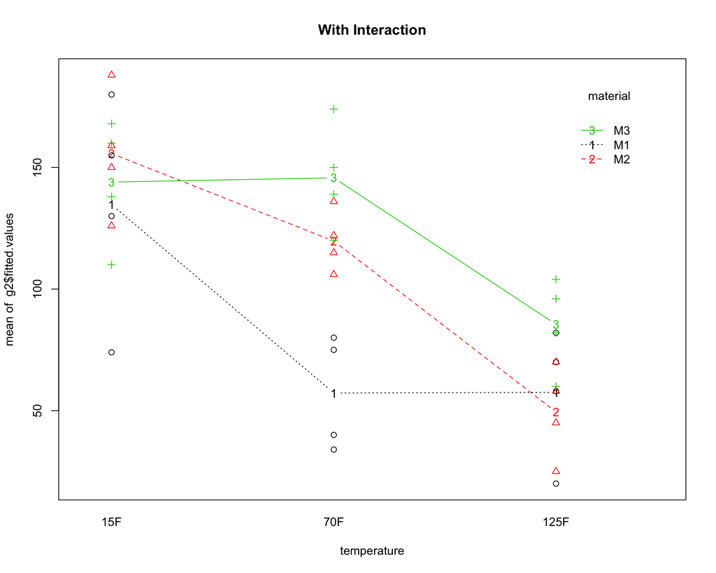

```r
g2 <- lm(response ~ material*temperature, battery)
interaction.plot(temperature,material,  g2$fitted.values, col = 1:3,
                 ylim = range (response),main = "With Interaction",
                 type = "b")
points (temperature, response, col = material, pch = as.numeric(material))
```

```r
summary(g2)
```

```
##
## Call:
## lm(formula = response ~ material * temperature, data = battery)
##
## Residuals:
##     Min      1Q  Median      3Q     Max
## -60.750 -14.625   1.375  17.938  45.250
##
## Coefficients:
##                            Estimate Std. Error t value Pr(>|t|)
## (Intercept)                  134.75      12.99  10.371 6.46e-11 ***
## materialM2                    21.00      18.37   1.143 0.263107
## materialM3                     9.25      18.37   0.503 0.618747
## temperature70F               -77.50      18.37  -4.218 0.000248 ***
## temperature125F              -77.25      18.37  -4.204 0.000257 ***
## materialM2:temperature70F     41.50      25.98   1.597 0.121886
## materialM3:temperature70F     79.25      25.98   3.050 0.005083 **
## materialM2:temperature125F   -29.00      25.98  -1.116 0.274242
## materialM3:temperature125F    18.75      25.98   0.722 0.476759
## ---
## Signif. codes:  0 '***' 0.001 '**' 0.01 '*' 0.05 '.' 0.1 ' ' 1
##
## Residual standard error: 25.98 on 27 degrees of freedom
## Multiple R-squared:  0.7652, Adjusted R-squared:  0.6956
## F-statistic:    11 on 8 and 27 DF,  p-value: 9.426e-07
```

```r
data.frame(model.matrix(g2))
```

| X.Intercept. | materialM2 | materialM3 | temperature70F | temperature125F | materialM2.temperature70F | materialM3.temperature70F | materialM2.temperature125F | materialM3.temperature125F |
| --- | --- | --- | --- | --- | --- | --- | --- | --- |
| 1 | 0 | 0 | 0 | 0 | 0 | 0 | 0 | 0 |
| 1 | 0 | 0 | 0 | 0 | 0 | 0 | 0 | 0 |
| 1 | 0 | 0 | 0 | 0 | 0 | 0 | 0 | 0 |
| 1 | 0 | 0 | 0 | 0 | 0 | 0 | 0 | 0 |
| 1 | 0 | 0 | 1 | 0 | 0 | 0 | 0 | 0 |
| 1 | 0 | 0 | 1 | 0 | 0 | 0 | 0 | 0 |
| 1 | 0 | 0 | 1 | 0 | 0 | 0 | 0 | 0 |
| 1 | 0 | 0 | 1 | 0 | 0 | 0 | 0 | 0 |
| 1 | 0 | 0 | 0 | 1 | 0 | 0 | 0 | 0 |
| 1 | 0 | 0 | 0 | 1 | 0 | 0 | 0 | 0 |
| 1 | 0 | 0 | 0 | 1 | 0 | 0 | 0 | 0 |
| 1 | 0 | 0 | 0 | 1 | 0 | 0 | 0 | 0 |
| 1 | 1 | 0 | 0 | 0 | 0 | 0 | 0 | 0 |
| 1 | 1 | 0 | 0 | 0 | 0 | 0 | 0 | 0 |
| 1 | 1 | 0 | 0 | 0 | 0 | 0 | 0 | 0 |
| 1 | 1 | 0 | 0 | 0 | 0 | 0 | 0 | 0 |
| 1 | 1 | 0 | 1 | 0 | 1 | 0 | 0 | 0 |
| 1 | 1 | 0 | 1 | 0 | 1 | 0 | 0 | 0 |
| 1 | 1 | 0 | 1 | 0 | 1 | 0 | 0 | 0 |
| 1 | 1 | 0 | 1 | 0 | 1 | 0 | 0 | 0 |
| 1 | 1 | 0 | 0 | 1 | 0 | 0 | 1 | 0 |
| 1 | 1 | 0 | 0 | 1 | 0 | 0 | 1 | 0 |
| 1 | 1 | 0 | 0 | 1 | 0 | 0 | 1 | 0 |
| 1 | 1 | 0 | 0 | 1 | 0 | 0 | 1 | 0 |
| 1 | 0 | 1 | 0 | 0 | 0 | 0 | 0 | 0 |
| 1 | 0 | 1 | 0 | 0 | 0 | 0 | 0 | 0 |
| 1 | 0 | 1 | 0 | 0 | 0 | 0 | 0 | 0 |
| 1 | 0 | 1 | 0 | 0 | 0 | 0 | 0 | 0 |
| 1 | 0 | 1 | 1 | 0 | 0 | 1 | 0 | 0 |
| 1 | 0 | 1 | 1 | 0 | 0 | 1 | 0 | 0 |
| 1 | 0 | 1 | 1 | 0 | 0 | 1 | 0 | 0 |
| 1 | 0 | 1 | 1 | 0 | 0 | 1 | 0 | 0 |
| 1 | 0 | 1 | 0 | 1 | 0 | 0 | 0 | 1 |
| 1 | 0 | 1 | 0 | 1 | 0 | 0 | 0 | 1 |
| 1 | 0 | 1 | 0 | 1 | 0 | 0 | 0 | 1 |
| 1 | 0 | 1 | 0 | 1 | 0 | 0 | 0 | 1 |

## 2.4 ANOVA

```r
# ANOVA table for additive models
anova.R2(g_additive)
```

|  | Df | Sum Sq | Mean Sq | F value | Pr(>F) | R2 |
| --- | --- | --- | --- | --- | --- | --- |
| material | 2 | 10683.72 | 5341.8611 | 5.947226 | 0.0065146 | 0.1375935 |
| temperature | 2 | 39118.72 | 19559.3611 | 21.775920 | 0.0000012 | 0.5038023 |
| Residuals | 31 | 27844.53 | 898.2106 | NA | NA | 0.3586042 |

```r
# ANOVA table for interaction models
anova.R2(g)
```

|  | Df | Sum Sq | Mean Sq | F value | Pr(>F) | R2 |
| --- | --- | --- | --- | --- | --- | --- |
| material | 2 | 10683.722 | 5341.861 | 7.911372 | 0.0019761 | 0.1375935 |
| temperature | 2 | 39118.722 | 19559.361 | 28.967692 | 0.0000002 | 0.5038023 |
| material:temperature | 4 | 9613.778 | 2403.444 | 3.559535 | 0.0186112 | 0.1238139 |
| Residuals | 27 | 18230.750 | 675.213 | NA | NA | 0.2347902 |

```r
# ANOVA for g2 for interaction models

anova.R2(g2)
```

|  | Df | Sum Sq | Mean Sq | F value | Pr(>F) | R2 |
| --- | --- | --- | --- | --- | --- | --- |
| material | 2 | 10683.722 | 5341.861 | 7.911372 | 0.0019761 | 0.1375935 |
| temperature | 2 | 39118.722 | 19559.361 | 28.967692 | 0.0000002 | 0.5038023 |
| material:temperature | 4 | 9613.778 | 2403.444 | 3.559535 | 0.0186112 | 0.1238139 |
| Residuals | 27 | 18230.750 | 675.213 | NA | NA | 0.2347902 |

```r
# The interaction SS is the difference of RSS from g_additive to g
anova (g_additive, g)
```

| Res.Df | RSS | Df | Sum of Sq | F | Pr(>F) |
| --- | --- | --- | --- | --- | --- |
| 31 | 27844.53 | NA | NA | NA | NA |
| 27 | 18230.75 | 4 | 9613.778 | 3.559535 | 0.0186112 |

## 2.5 Effect Comparison with Tukey Method

```r
TukeyHSD(aov(response ~ material*temperature, battery))
```

```
##   Tukey multiple comparisons of means
##     95% family-wise confidence level
##
## Fit: aov(formula = response ~ material * temperature, data = battery)
##
## $material
##           diff       lwr      upr     p adj
## M2-M1 25.16667 -1.135677 51.46901 0.0627571
## M3-M1 41.91667 15.614323 68.21901 0.0014162
## M3-M2 16.75000 -9.552344 43.05234 0.2717815
##
## $temperature
##               diff        lwr       upr     p adj
## 70F-15F  -37.25000  -63.55234 -10.94766 0.0043788
## 125F-15F -80.66667 -106.96901 -54.36432 0.0000001
## 125F-70F -43.41667  -69.71901 -17.11432 0.0009787
##
## $`material:temperature`
##                    diff         lwr        upr     p adj
## M2:15F-M1:15F     21.00  -40.823184  82.823184 0.9616404
## M3:15F-M1:15F      9.25  -52.573184  71.073184 0.9998527
## M1:70F-M1:15F    -77.50 -139.323184 -15.676816 0.0065212
## M2:70F-M1:15F    -15.00  -76.823184  46.823184 0.9953182
## M3:70F-M1:15F     11.00  -50.823184  72.823184 0.9994703
## M1:125F-M1:15F   -77.25 -139.073184 -15.426816 0.0067471
## M2:125F-M1:15F   -85.25 -147.073184 -23.426816 0.0022351
## M3:125F-M1:15F   -49.25 -111.073184  12.573184 0.2016535
## M3:15F-M2:15F    -11.75  -73.573184  50.073184 0.9991463
## M1:70F-M2:15F    -98.50 -160.323184 -36.676816 0.0003449
## M2:70F-M2:15F    -36.00  -97.823184  25.823184 0.5819453
## M3:70F-M2:15F    -10.00  -71.823184  51.823184 0.9997369
## M1:125F-M2:15F   -98.25 -160.073184 -36.426816 0.0003574
## M2:125F-M2:15F  -106.25 -168.073184 -44.426816 0.0001152
## M3:125F-M2:15F   -70.25 -132.073184  -8.426816 0.0172076
## M1:70F-M3:15F    -86.75 -148.573184 -24.926816 0.0018119
## M2:70F-M3:15F    -24.25  -86.073184  37.573184 0.9165175
## M3:70F-M3:15F      1.75  -60.073184  63.573184 1.0000000
## M1:125F-M3:15F   -86.50 -148.323184 -24.676816 0.0018765
## M2:125F-M3:15F   -94.50 -156.323184 -32.676816 0.0006078
## M3:125F-M3:15F   -58.50 -120.323184   3.323184 0.0742711
## M2:70F-M1:70F     62.50    0.676816 124.323184 0.0460388
## M3:70F-M1:70F     88.50   26.676816 150.323184 0.0014173
## M1:125F-M1:70F     0.25  -61.573184  62.073184 1.0000000
## M2:125F-M1:70F    -7.75  -69.573184  54.073184 0.9999614
## M3:125F-M1:70F    28.25  -33.573184  90.073184 0.8281938
## M3:70F-M2:70F     26.00  -35.823184  87.823184 0.8822881
## M1:125F-M2:70F   -62.25 -124.073184  -0.426816 0.0474675
## M2:125F-M2:70F   -70.25 -132.073184  -8.426816 0.0172076
## M3:125F-M2:70F   -34.25  -96.073184  27.573184 0.6420441
## M1:125F-M3:70F   -88.25 -150.073184 -26.426816 0.0014679
## M2:125F-M3:70F   -96.25 -158.073184 -34.426816 0.0004744
## M3:125F-M3:70F   -60.25 -122.073184   1.573184 0.0604247
## M2:125F-M1:125F   -8.00  -69.823184  53.823184 0.9999508
## M3:125F-M1:125F   28.00  -33.823184  89.823184 0.8347331
## M3:125F-M2:125F   36.00  -25.823184  97.823184 0.5819453
```

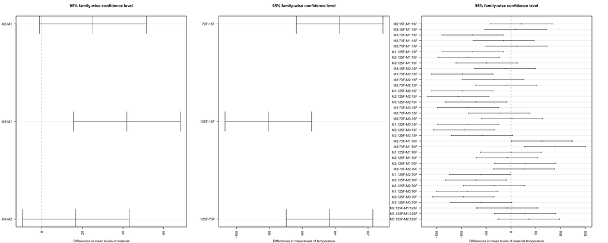

```r
par (mfrow=c(1,3), mar=c(4,4,4,4))
plot(TukeyHSD(aov(response ~ material*temperature, battery)), las=2)
```

### 2.5.1 Computing Tukey’s CIs

$$se(\hat \mu_i-\hat \mu_j)=\hat\sigma\times \sqrt{1/n_i+1/n_j}$$
where $\hat\sigma=\sqrt{MSE}$ from the interaction model, where $n_i$ and $n_j$ are the sample sizes in $\hat \mu_i$ and $\hat \mu_j$. This SE will be multiplied by the t quantile or Tukey quantiles to obtain the LSD CI or family-wise CI. # Comparing Main Effects of Materials

Tabular summary of the dataset:

```r
tapply(response, INDEX = list ( material, temperature), mean) -> battery.means
cbind(battery.means, rowMeans(battery.means)) -> battery.means1
rbind(battery.means1, colMeans(battery.means1)) -> battery.means2
battery.means2
```

```
##         15F      70F     125F
## M1 134.7500  57.2500 57.50000  83.16667
## M2 155.7500 119.7500 49.50000 108.33333
## M3 144.0000 145.7500 85.50000 125.08333
##    144.8333 107.5833 64.16667 105.52778
```

```r
table(material,temperature)
```

```
##         temperature
## material 15F 70F 125F
##       M1   4   4    4
##       M2   4   4    4
##       M3   4   4    4
```

Computing SE and ME:

```r
se <- sigma (g) * sqrt(1/12+1/12); se
```

```
## [1] 10.60827
```

```r
# number of means to select is 3
ME <- se * qtukey(0.95, 3, g$df.residual) / sqrt(2)

# Comparing means between temperatures

# CI for main effects between temperature 15F to temperature 70F
battery.means2[4,1] -battery.means2[4,2]  + c (-ME, +ME)
```

```
## [1] 10.94766 63.55234
```

```r
# Comparing means between materials

# CI for main effects between material 1 and material 2
battery.means2[1,4] -battery.means2[2,4]  + c (-ME, +ME)
```

```
## [1] -51.469011   1.135677
```

```r
# for comparing means for all combinations of "material" and "temperature"
# 4 is number of replicates
se2 <- sigma (g) * sqrt(1/4+1/4); se2
```

```
## [1] 18.37407
```

```r
ME2 <- se2 * qtukey (0.95, 9, g$df.residual) / sqrt(2)


battery.means[2,3]-battery.means[1,1] + c(-ME2, ME2)
```

```
## [1] -147.07318  -23.42682
```

## 2.6 Model Checking

```r
par(mfrow=c(1,2))
qqnorm(g$residuals)
qqline(g$residuals)
shapiro.test(g$residuals)
```

```
##
##  Shapiro-Wilk normality test
##
## data:  g$residuals
## W = 0.97606, p-value = 0.6117
```

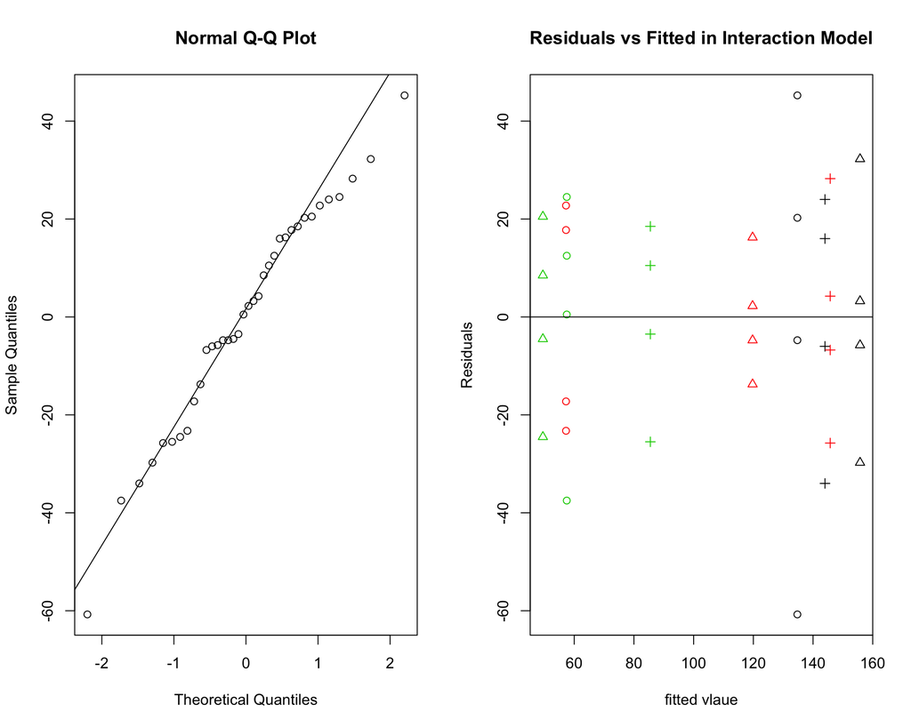

```r
plot(g$fit,g$res,xlab="fitted vlaue", ylab="Residuals",
     col = temperature,  pch = as.numeric(material),
     main = "Residuals vs Fitted in Interaction Model");
abline (h = 0)
```

```r
detach ("battery")
```

# 3 Tukey’s Nonadditive Test for Factorial Experiments with a Single Replicate

```r
tukeydata <- read.table("data/tukeydata.txt", header=T)
tukeydata
```

| temperature | pressure | y |
| --- | --- | --- |
| t100 | p25 | 5 |
| t100 | p30 | 4 |
| t100 | p35 | 6 |
| t100 | p40 | 3 |
| t100 | p45 | 5 |
| t125 | p25 | 3 |
| t125 | p30 | 1 |
| t125 | p35 | 4 |
| t125 | p40 | 2 |
| t125 | p45 | 3 |
| t150 | p25 | 1 |
| t150 | p30 | 1 |
| t150 | p35 | 3 |
| t150 | p40 | 1 |
| t150 | p45 | 2 |

```r
attach(tukeydata)
```

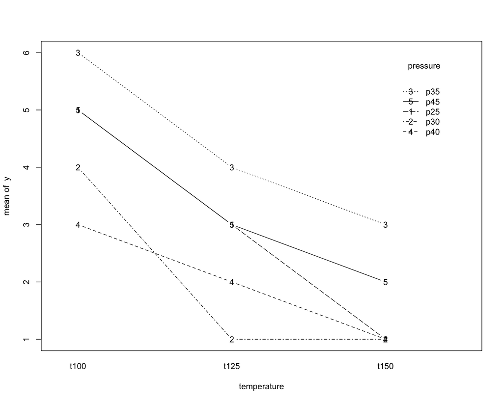

```r
par (mfrow=c(1,1))
interaction.plot(temperature, pressure,y, type = "b")
```

```r
table (temperature, pressure)
```

```
##            pressure
## temperature p25 p30 p35 p40 p45
##        t100   1   1   1   1   1
##        t125   1   1   1   1   1
##        t150   1   1   1   1   1
```

```r
names(tukeydata)
```

```
## [1] "temperature" "pressure"    "y"
```

```r
g<-lm(y~temperature+pressure)
anova(g)
```

|  | Df | Sum Sq | Mean Sq | F value | Pr(>F) |
| --- | --- | --- | --- | --- | --- |
| temperature | 2 | 23.33333 | 11.66667 | 46.66667 | 0.0000388 |
| pressure | 4 | 11.60000 | 2.90000 | 11.60000 | 0.0020634 |
| Residuals | 8 | 2.00000 | 0.25000 | NA | NA |

```r
library(agricolae)
#We need to supply the degree freedom and values of MSE from the additive model, which are 8 and 0.25 respectively.
nonadditivity(y, temperature, pressure, 8, 0.25)
```

```
##
## Tukey's test of nonadditivity
## y
##
## P : 2.666667
## Q : 72.17778
##
## Analysis of Variance Table
##
## Response: residual
##               Df  Sum Sq  Mean Sq F value Pr(>F)
## Nonadditivity  1 0.09852 0.098522  0.3627  0.566
## Residuals      7 1.90148 0.271640
```

```
## $P
## Nonadditivity
##      2.666667
##
## $Q
## Nonadditivity
##      72.17778
##
## $ANOVA
## Analysis of Variance Table
##
## Response: residual
##               Df  Sum Sq  Mean Sq F value Pr(>F)
## Nonadditivity  1 0.09852 0.098522  0.3627  0.566
## Residuals      7 1.90148 0.271640
```

```r
detach ("tukeydata")
```